# Texas Removed 8.5 Percent Cap on Special Education Enrollments, but Still Lags Behind National Average

### In 2016, the Houston Chronicle published a multi-part series called [Denied](https://www.houstonchronicle.com/denied/1/) that outlined how a Texas Education Agency policy started in 2004 could force an audit of schools that have more than 8.5% of their students in special education programs.

###Following the Chronicle’s reporting (along with other news orgs), the Texas Legislature in 2017 [unanimously banned](https://www.chron.com/news/houston-texas/houston/article/Legislature-unanimously-approves-bill-designed-to-11134046.php) using a target or benchmark on how many students a district or charter school enrolls in special education.

###The Texas House passed Senate Bill 160 in 2017, designed to terminate all school districts from imposing an 8.5 percent cap on the number of students who can enroll in special education. By the end of 2021, the number of school districts in the state that offer limited special education services went down to 112, around one-tenth of all districts.

###According to Texas Academic Performance Reports from 2013 to 2021, the impacts of the bill have been phenomenal. Among 1,021 school districts in Texas, the number of districts that have not delayed or denied special education to disabled students went up from 591 to 909, a nearly 54% increase, by the end of 2021.

###The year of 2017 became a big turning point. Over the past five years, the fluctuation in the number of schools that went below the 8.5 percent benchmark had never exceeded 20. However, during governmental implementation, the number of schools receiving special education ballooned by 51.

###Although the Texas Education Agency reports that the number of students receiving special education services is escalating, the state remains below the [national average of 13 percent](https://www.houstonchronicle.com/denied/1/) five years after the cap was lifted. The number has gone from 8.6 percent in the 2012-2013 school year to 11.3 percent for the 2020-2021 school year.

### About the data

Each year, the Texas Education Agency publishes the percentage of students in special education as part of their [Texas Academic Performance Reports](https://tea.texas.gov/texas-schools/accountability/academic-accountability/performance-reporting/texas-academic-performance-reports).

## Setting up

```r
library(tidyverse)
library(scales)
library(DT)
```

## Import cleaned data

```r
sped <- read_rds("data-processed/01-sped.rds")

sped  |> head()
```

| district | distname | cntyname | year | all_count | sped_count | sped_percent | audit_flag |
| --- | --- | --- | --- | --- | --- | --- | --- |
| 001902 | CAYUGA ISD | ANDERSON | 2013 | 595 | 73 | 12.3 | ABOVE |
| 001902 | CAYUGA ISD | ANDERSON | 2014 | 553 | 76 | 13.7 | ABOVE |
| 001902 | CAYUGA ISD | ANDERSON | 2015 | 577 | 76 | 13.2 | ABOVE |
| 001902 | CAYUGA ISD | ANDERSON | 2016 | 568 | 78 | 13.7 | ABOVE |
| 001902 | CAYUGA ISD | ANDERSON | 2017 | 576 | 82 | 14.2 | ABOVE |
| 001902 | CAYUGA ISD | ANDERSON | 2018 | 575 | 83 | 14.4 | ABOVE |

## Creating a searchable table with pivot_wide function

```r
district_percents_data <- sped |>
  select(distname, cntyname, year, sped_percent) |>
  pivot_wider(names_from = year, values_from = sped_percent)


district_percents_data
```

| distname | cntyname | 2013 | 2014 | 2015 | 2016 | 2017 | 2018 | 2019 | 2020 | 2021 |
| --- | --- | --- | --- | --- | --- | --- | --- | --- | --- | --- |
| CAYUGA ISD | ANDERSON | 12.3 | 13.7 | 13.2 | 13.7 | 14.2 | 14.4 | 14.9 | 14.7 | 14.6 |
| ELKHART ISD | ANDERSON | 9.1 | 8.9 | 10.4 | 11.6 | 11.0 | 10.5 | 10.7 | 11.8 | 12.3 |
| FRANKSTON ISD | ANDERSON | 10.8 | 9.7 | 9.7 | 8.2 | 8.9 | 10.1 | 11.5 | 11.6 | 12.8 |
| NECHES ISD | ANDERSON | 11.1 | 9.0 | 11.1 | 11.0 | 9.8 | 9.7 | 8.7 | 7.1 | 9.2 |
| PALESTINE ISD | ANDERSON | 7.7 | 7.8 | 8.7 | 8.5 | 8.8 | 9.2 | 10.7 | 11.6 | 12.9 |
| WESTWOOD ISD | ANDERSON | 9.3 | 10.0 | 9.3 | 9.9 | 10.6 | 10.8 | 12.3 | 14.0 | 14.3 |
| SLOCUM ISD | ANDERSON | 10.9 | 11.9 | 12.3 | 13.0 | 12.7 | 12.5 | 12.3 | 13.4 | 13.9 |
| ANDREWS ISD | ANDREWS | 6.9 | 6.6 | 6.4 | 6.5 | 7.1 | 7.2 | 8.0 | 8.5 | 9.4 |
| HUDSON ISD | ANGELINA | 7.2 | 6.2 | 7.1 | 7.6 | 7.5 | 8.4 | 8.6 | 9.0 | 10.7 |
| LUFKIN ISD | ANGELINA | 10.6 | 10.5 | 10.5 | 10.5 | 10.3 | 10.4 | 10.8 | 11.6 | 12.0 |

[output cut: 1011 more lines]

## Creating a datatable

```r
district_percents_data |>
  datatable()
```

|  | distname | cntyname | 2013 | 2014 | 2015 | 2016 | 2017 | 2018 | 2019 | 2020 | 2021 |
| --- | --- | --- | --- | --- | --- | --- | --- | --- | --- | --- | --- |
| 1 | CAYUGA ISD | ANDERSON | 12.3 | 13.7 | 13.2 | 13.7 | 14.2 | 14.4 | 14.9 | 14.7 | 14.6 |
| 2 | ELKHART ISD | ANDERSON | 9.1 | 8.9 | 10.4 | 11.6 | 11 | 10.5 | 10.7 | 11.8 | 12.3 |
| 3 | FRANKSTON ISD | ANDERSON | 10.8 | 9.7 | 9.7 | 8.2 | 8.9 | 10.1 | 11.5 | 11.6 | 12.8 |
| 4 | NECHES ISD | ANDERSON | 11.1 | 9 | 11.1 | 11 | 9.8 | 9.7 | 8.7 | 7.1 | 9.2 |
| 5 | PALESTINE ISD | ANDERSON | 7.7 | 7.8 | 8.7 | 8.5 | 8.8 | 9.2 | 10.7 | 11.6 | 12.9 |
| 6 | WESTWOOD ISD | ANDERSON | 9.3 | 10 | 9.3 | 9.9 | 10.6 | 10.8 | 12.3 | 14 | 14.3 |
| 7 | SLOCUM ISD | ANDERSON | 10.9 | 11.9 | 12.3 | 13 | 12.7 | 12.5 | 12.3 | 13.4 | 13.9 |
| 8 | ANDREWS ISD | ANDREWS | 6.9 | 6.6 | 6.4 | 6.5 | 7.1 | 7.2 | 8 | 8.5 | 9.4 |
| 9 | HUDSON ISD | ANGELINA | 7.2 | 6.2 | 7.1 | 7.6 | 7.5 | 8.4 | 8.6 | 9 | 10.7 |
| 10 | LUFKIN ISD | ANGELINA | 10.6 | 10.5 | 10.5 | 10.5 | 10.3 | 10.4 | 10.8 | 11.6 | 12 |

[output cut: 1011 more lines]

- In 2020, Austin ISD reached to 12.8%.

## Build the statewide percentage by year data

- We’re building charts to answer the following question: Has the percentage of special education students in Texas changed since the benchmarking policy was dropped?

```r
yearly_percent <- sped |>
  group_by(year) |>
  summarise(
    total_students = sum(all_count),
    total_sped = sum(sped_count)
  ) |>
  mutate(sped_percent = ((total_sped / total_students) * 100) |> round(1))

yearly_percent
```

| year | total_students | total_sped | sped_percent |
| --- | --- | --- | --- |
| 2013 | 4870038 | 418360 | 8.6 |
| 2014 | 4929867 | 420847 | 8.5 |
| 2015 | 4984714 | 427377 | 8.6 |
| 2016 | 5034274 | 437487 | 8.7 |
| 2017 | 5070664 | 449303 | 8.9 |
| 2018 | 5088351 | 468097 | 9.2 |
| 2019 | 5099385 | 499240 | 9.8 |
| 2020 | 5142334 | 551718 | 10.7 |
| 2021 | 4993274 | 566484 | 11.3 |

## Building the statewide percentage chart

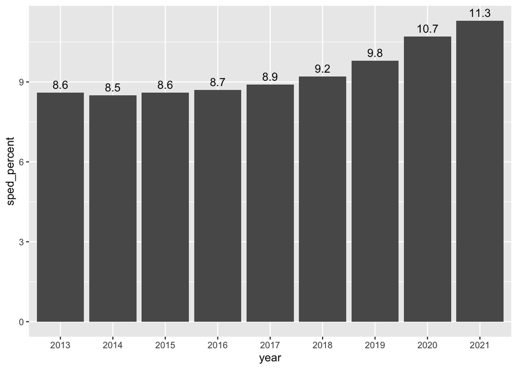

```r
yearly_percent |>
  ggplot(aes(x = year, y = sped_percent)) +
  geom_col() +
  geom_text(aes(label = sped_percent, vjust = -.5))
```

## Build the audit flag data

- We are summarize a new table to answer the following question: How many districts were above that arbitrary 8.5% benchmark before and after the changes?
- ps. count() has the same function as GSA

```r
flag_count_districts <- sped |>
  count(year, audit_flag, name = "count_districts")

flag_count_districts
```

| year | audit_flag | count_districts |
| --- | --- | --- |
| 2013 | ABOVE | 591 |
| 2013 | BELOW | 429 |
| 2014 | ABOVE | 571 |
| 2014 | BELOW | 449 |
| 2015 | ABOVE | 579 |
| 2015 | BELOW | 441 |
| 2016 | ABOVE | 578 |
| 2016 | BELOW | 442 |
| 2017 | ABOVE | 629 |
| 2017 | BELOW | 391 |

[output cut: 8 more lines]

## Build the audit flag chart

- Part 1: Stacked column chart

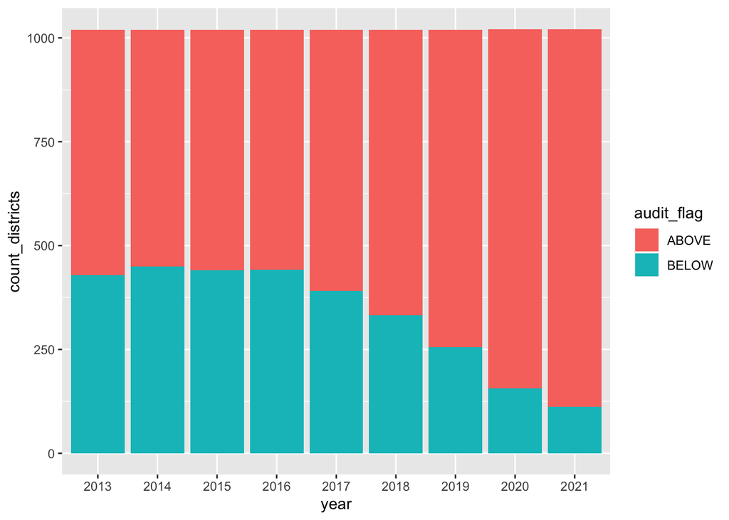

```r
flag_count_districts |>
  ggplot(aes(x = year, y = count_districts, fill = audit_flag)) +
  geom_col()
```

- Part 2: Grouped column chart (the best chart to explain the question)

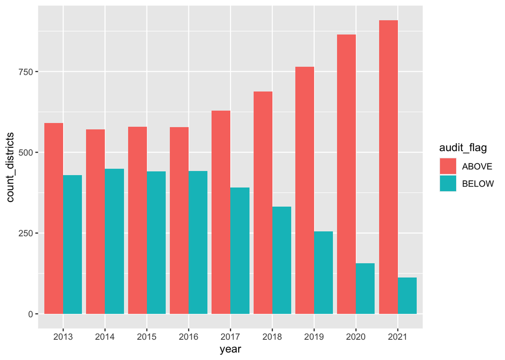

```r
flag_count_districts |>
  ggplot(aes(x = year, y = count_districts, fill = audit_flag)) +
  geom_col(position = "dodge")
```

- Part 3: Visualizing with line chart
  1. ylim() added because the default didn’t start the y axis at zero.
  2. ylim() is a shortcut for scale_y_continuous(limits = c(0,1000))

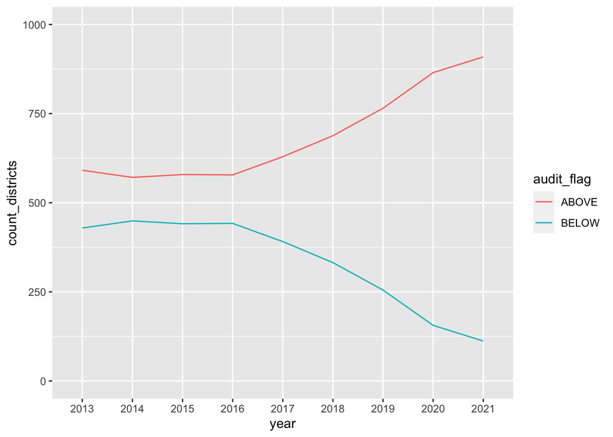

```r
flag_count_districts |>
  ggplot(aes(x = year, y = count_districts, group = audit_flag)) +
  geom_line(aes(color = audit_flag)) +
  ylim(0,1000)
```

## Changes in local districts

- Changes in Bastrop district

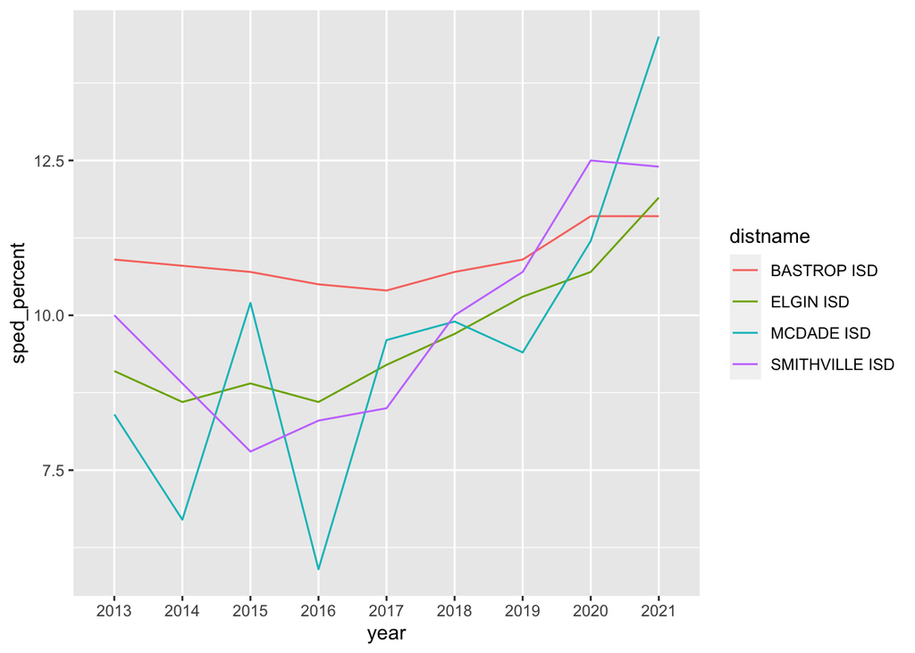

```r
change_bastrop <- sped |>
  filter(cntyname == "BASTROP") |>
  ggplot(aes(x = year, y = sped_percent, group = distname)) +
  geom_line(aes(color = distname))

change_bastrop
```

- Changes in Hays district

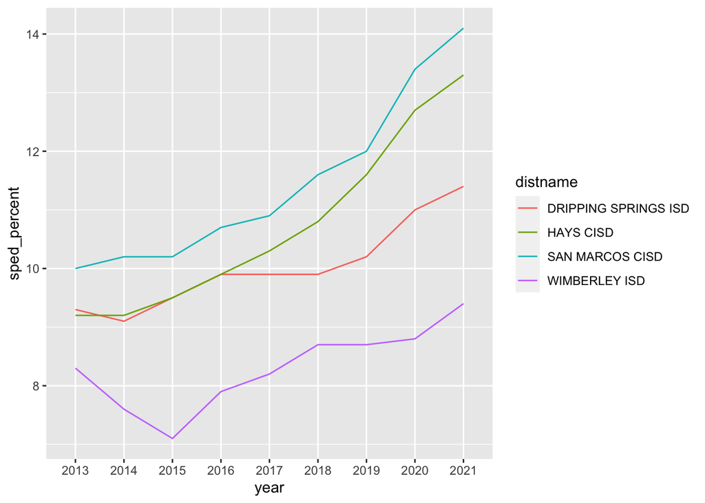

```r
change_hays <- sped |>
  filter(cntyname == "HAYS") |>
  ggplot(aes(x = year, y = sped_percent, group = distname)) +
  geom_line(aes(color = distname))

change_hays
```

- Changes in Travis

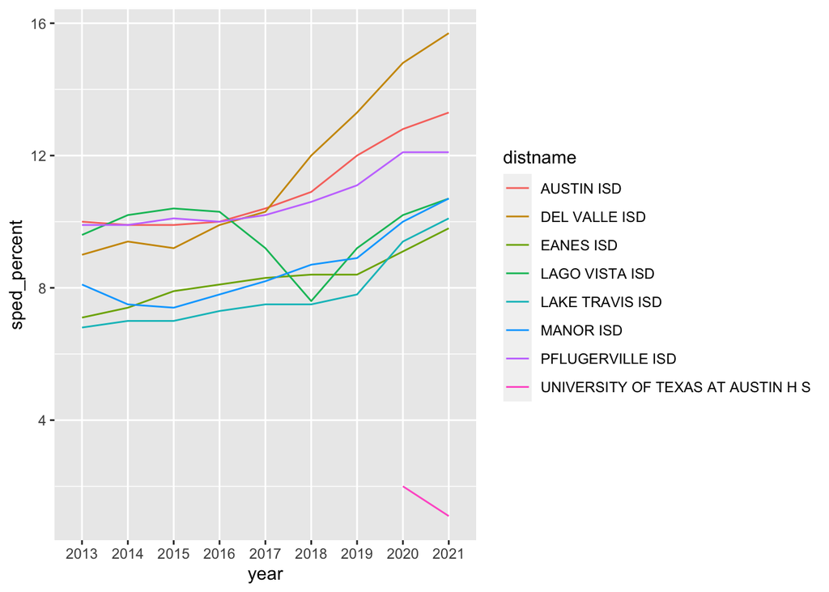

```r
change_travis <- sped |>
  filter(cntyname == "TRAVIS") |>
  ggplot(aes(x = year, y = sped_percent, group = distname)) +
  geom_line(aes(color = distname))

change_travis
```

- Changes in Williamson

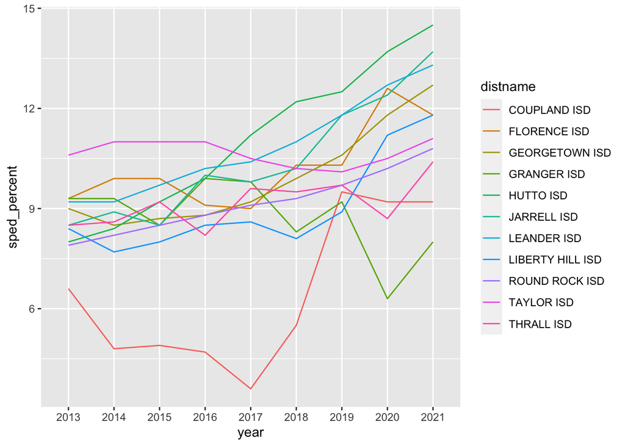

```r
change_williamson <- sped |>
  filter(cntyname == "WILLIAMSON") |>
  ggplot(aes(x = year, y = sped_percent, group = distname)) +
  geom_line(aes(color = distname))

change_williamson
```